# Taller_Analisis_Factorial_I

Juan Pablo Mosquera Marin - 20221020026 Ana Laura Morcote Chacon - 20221020010 Hana Sofia Pinilla Manrique - 20221020092 Juan David Amaya Patiño - 20221020057

2026-10-17

# Cálculo del KMO con las variables numéricas

```r
datos_credit <- tryCatch(
  {
    readr::read_csv(here::here("DATASET", "datos_credit.csv"), show_col_types = FALSE)
  },
  error = function(e) {
    readr::read_csv(here::here("GitHub", "ESTAD.-MULTI", "DATASET", "datos_credit.csv"), show_col_types = FALSE)
  }
)

variables_todas <- c(
  "LIMIT_BAL", "AGE",
  paste0("BILL_AMT", 1:6),
  paste0("PAY_AMT", 1:6)
)

datos_kmo_todas <- as.data.frame(datos_credit[, variables_todas])
stopifnot(all(vapply(datos_kmo_todas, is.numeric, logical(1))))

datos_kmo_todas <- datos_kmo_todas[complete.cases(datos_kmo_todas), , drop = FALSE]
matriz_correlaciones_todas <- cor(datos_kmo_todas, method = "pearson")

resultado_kmo_todas <- psych::KMO(matriz_correlaciones_todas)

resultado_kmo_todas
```

```
## Kaiser-Meyer-Olkin factor adequacy
## Call: psych::KMO(r = matriz_correlaciones_todas)
## Overall MSA =  0.76
## MSA for each item =
## LIMIT_BAL       AGE BILL_AMT1 BILL_AMT2 BILL_AMT3 BILL_AMT4 BILL_AMT5 BILL_AMT6
##      0.92      0.69      0.84      0.77      0.80      0.84      0.79      0.82
##  PAY_AMT1  PAY_AMT2  PAY_AMT3  PAY_AMT4  PAY_AMT5  PAY_AMT6
##      0.48      0.36      0.48      0.48      0.39      0.76
```

Adecuación para el análisis factorial: KMO global y MSA por variable.

| Indicador / variable | KMO / MSA | Adecuación |
| --- | --- | --- |
| **RESULTADO GLOBAL · Adecuación del conjunto** |  |  |
| KMO global · Conjunto de las variables numéricas | 0,757 | Aceptable |
| **PERFIL DEL CLIENTE · Límite de crédito y edad** |  |  |
| LIMIT_BAL · Límite de crédito | 0,921 | Excelente |
| AGE · Edad | 0,690 | Regular |
| **FACTURACIÓN · Montos de los estados de cuenta** |  |  |
| BILL_AMT1 · Septiembre | 0,836 | Muy buena |
| BILL_AMT2 · Agosto | 0,773 | Aceptable |
| BILL_AMT3 · Julio | 0,800 | Muy buena |
| BILL_AMT4 · Junio | 0,841 | Muy buena |
| BILL_AMT5 · Mayo | 0,790 | Aceptable |
| BILL_AMT6 · Abril | 0,823 | Muy buena |
| **PAGOS · Montos efectivamente pagados** |  |  |
| PAY_AMT1 · Septiembre | 0,477 | Inadecuada |
| PAY_AMT2 · Agosto | 0,365 | Inadecuada |
| PAY_AMT3 · Julio | 0,483 | Inadecuada |
| PAY_AMT4 · Junio | 0,481 | Inadecuada |
| PAY_AMT5 · Mayo | 0,392 | Inadecuada |
| PAY_AMT6 · Abril | 0,756 | Aceptable |

Nota: Criterio orientativo: [0,90; 1] excelente; [0,80; 0,90) muy buena; [0,70; 0,80) aceptable; [0,60; 0,70) regular; [0,50; 0,60) baja; menos de 0,50 inadecuada.

Dado que el objetivo del banco taiwanés es intervenir tempranamente sobre los clientes con riesgo de incumplimiento de pago, el KMO permite concluir lo siguiente:

- *LIMIT_BAL*, *PAY_AMT6* y *BILL_AMT1* a *BILL_AMT6* presentan una adecuación aceptable o muy buena. Por eso son las candidatas a conservar para explorar factores asociados con la información crediticia, los pagos y el endeudamiento.
- *LIMIT_BAL* tiene la mayor adecuación individual (0,921), lo que asegura su inclusión. Sin embargo, una alta adecuación para el análisis factorial no implica que sea la variable con mayor peso para predecir el incumplimiento.
- *AGE* tiene un MSA regular, pero se conserva porque permite perfilar al cliente mediante un atributo propio de él.
- *PAY_AMT1* a *PAY_AMT5* tienen un MSA inferior a 0,50, por lo que no son adecuadas para el análisis factorial. Esto no les resta valor para identificar clientes que podrían incumplir.

# KMO sin PAY_AMT1 a PAY_AMT5

```r
# Retirar PAY_AMT1 a PAY_AMT5 y conservar solo PAY_AMT6.
variables <- c(
  "LIMIT_BAL",
  "AGE",
  paste0("BILL_AMT", 1:6),
  "PAY_AMT6"
)

datos_kmo <- as.data.frame(datos_credit[, variables])
stopifnot(all(vapply(datos_kmo, is.numeric, logical(1))))

datos_kmo <- datos_kmo[complete.cases(datos_kmo), , drop = FALSE]
matriz_correlaciones <- cor(datos_kmo, method = "pearson")

resultado_kmo <- psych::KMO(matriz_correlaciones)

resultado_kmo
```

```
## Kaiser-Meyer-Olkin factor adequacy
## Call: psych::KMO(r = matriz_correlaciones)
## Overall MSA =  0.89
## MSA for each item =
## LIMIT_BAL       AGE BILL_AMT1 BILL_AMT2 BILL_AMT3 BILL_AMT4 BILL_AMT5 BILL_AMT6
##      0.91      0.67      0.88      0.86      0.93      0.92      0.86      0.89
##  PAY_AMT6
##      0.77
```

Adecuación para el análisis factorial con las variables conservadas.

| Indicador / variable | KMO / MSA | Adecuación |
| --- | --- | --- |
| **RESULTADO GLOBAL · Adecuación del conjunto** |  |  |
| KMO global · Variables conservadas | 0,889 | Muy buena |
| **PERFIL DEL CLIENTE · Límite de crédito y edad** |  |  |
| LIMIT_BAL · Límite de crédito | 0,907 | Excelente |
| AGE · Edad | 0,668 | Regular |
| **FACTURACIÓN · Montos de los estados de cuenta** |  |  |
| BILL_AMT1 · Septiembre | 0,882 | Muy buena |
| BILL_AMT2 · Agosto | 0,859 | Muy buena |
| BILL_AMT3 · Julio | 0,932 | Excelente |
| BILL_AMT4 · Junio | 0,917 | Excelente |
| BILL_AMT5 · Mayo | 0,860 | Muy buena |
| BILL_AMT6 · Abril | 0,892 | Muy buena |
| **PAGOS · Montos efectivamente pagados** |  |  |
| PAY_AMT6 · Abril | 0,773 | Aceptable |

Nota: Criterio orientativo: [0,90; 1] excelente; [0,80; 0,90) muy buena; [0,70; 0,80) aceptable; [0,60; 0,70) regular; [0,50; 0,60) baja; menos de 0,50 inadecuada.

Tras retirar las cinco variables de pagos (*PAY_AMT1*, *PAY_AMT2*, *PAY_AMT3*, *PAY_AMT4* y *PAY_AMT5*), el KMO global pasó de 0,757 a 0,889, lo que corresponde a una adecuación muy buena según nuestro criterio para explorar un análisis factorial. Además, todas las variables restantes presentan un MSA superior a 0,50.

Con estas nueve variables continuaremos con la extracción de factores y el examen de sus cargas, para establecer qué dimensiones representan. El KMO, por sí solo, no determina cuántos factores existen ni permite interpretarlos.

# Cálculo de parte común vs. parte propia

Para el modelo de un factor, la varianza de cada variable se divide en una parte común, explicada por el factor, y una parte propia, que corresponde a la varianza específica de la variable y al error.

```r
# Ajustar un factor por máxima verosimilitud con las nueve variables.
modelo_fa <- psych::fa(
  datos_kmo,
  nfactors = 1,
  fm = "ml",
  rotate = "none"
)

print(modelo_fa)
```

```
## Factor Analysis using method =  ml
## Call: psych::fa(r = datos_kmo, nfactors = 1, rotate = "none", fm = "ml")
## Standardized loadings (pattern matrix) based upon correlation matrix
##            ML1     h2    u2 com
## LIMIT_BAL 0.31 0.0932 0.907   1
## AGE       0.06 0.0031 0.997   1
## BILL_AMT1 0.91 0.8345 0.165   1
## BILL_AMT2 0.94 0.8853 0.115   1
## BILL_AMT3 0.95 0.9097 0.090   1
## BILL_AMT4 0.97 0.9355 0.065   1
## BILL_AMT5 0.95 0.9037 0.096   1
## BILL_AMT6 0.92 0.8513 0.149   1
## PAY_AMT6  0.18 0.0321 0.968   1
##
##                 ML1
## SS loadings    5.45
## Proportion Var 0.61
##
## Mean item complexity =  1
## Test of the hypothesis that 1 factor is sufficient.
##
## df null model =  36  with the objective function =  10.98 with Chi Square =  329479.9
## df of  the model are 27  and the objective function was  1.48
##
## The root mean square of the residuals (RMSR) is  0.04
## The df corrected root mean square of the residuals is  0.05
##
## The harmonic n.obs is  30000 with the empirical chi square  2092.23  with prob <  0
## The total n.obs was  30000  with Likelihood Chi Square =  44266.77  with prob <  0
##
## Tucker Lewis Index of factoring reliability =  0.821
## RMSEA index =  0.234  and the 90 % confidence intervals are  0.232 0.236
## BIC =  43988.43
## Fit based upon off diagonal values = 0.99
## Measures of factor score adequacy
##                                                    ML1
## Correlation of (regression) scores with factors   0.99
## Multiple R square of scores with factors          0.98
## Minimum correlation of possible factor scores     0.96
```

```r
# Parte común: proporción de varianza explicada por el factor.
# Parte propia: proporción de varianza no explicada por el factor.
tabla_varianzas <- data.frame(
  Variable = colnames(datos_kmo),
  Comun = unname(modelo_fa$communality),
  Propia = unname(modelo_fa$uniquenesses)
)
```

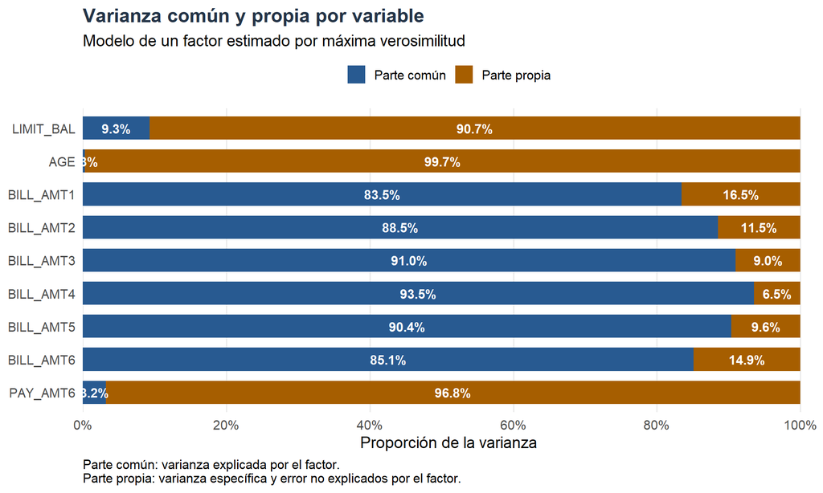

La variable *AGE* es casi toda parte propia: el 99,7 % de su varianza no es explicada por el factor y solo el 0,3 % es parte común. Esto indica que la edad prácticamente no comparte información con las demás variables. Mientras los montos facturados se mueven juntos y reflejan una misma dimensión (el nivel de endeudamiento), la edad se comporta de forma independiente.

Algo similar ocurre con *PAY_AMT6* y *LIMIT_BAL*, que también se explican mayoritariamente por sus propias características y comparten poca información con el factor.

Para el banco, esto significa que la edad no puede resumirse ni reemplazarse mediante el factor, porque aporta información distinta que no está contenida en las demás variables. Por tanto, si se desea usarla para identificar clientes con riesgo de incumplimiento, debe analizarse por separado y no a través del factor.

# Análisis de correlación y producto de cargas

Si el modelo de un factor fuera adecuado, la correlación entre dos variables debería ser aproximadamente igual al producto de sus cargas. La siguiente tabla compara, para cada pareja de variables, la correlación observada con el producto de cargas y calcula el error de reproducción (observada menos producto de cargas).

Correlación observada vs. producto de cargas (modelo de un factor) para todas las parejas.

| Variable 1 | Variable 2 | Observada | Producto de cargas | Error (obs. − prod.) |
| --- | --- | --- | --- | --- |
| LIMIT_BAL | PAY_AMT6 | 0,220 | 0,055 | 0,165 |
| LIMIT_BAL | AGE | 0,145 | 0,017 | 0,128 |
| BILL_AMT1 | BILL_AMT2 | 0,951 | 0,860 | 0,092 |
| BILL_AMT5 | BILL_AMT6 | 0,946 | 0,877 | 0,069 |
| BILL_AMT6 | PAY_AMT6 | 0,115 | 0,165 | -0,050 |
| BILL_AMT1 | BILL_AMT6 | 0,803 | 0,843 | -0,040 |
| BILL_AMT1 | BILL_AMT5 | 0,830 | 0,868 | -0,039 |
| BILL_AMT2 | BILL_AMT6 | 0,832 | 0,868 | -0,037 |
| BILL_AMT2 | BILL_AMT5 | 0,860 | 0,894 | -0,035 |
| BILL_AMT2 | BILL_AMT3 | 0,928 | 0,897 | 0,031 |
| BILL_AMT3 | BILL_AMT6 | 0,853 | 0,880 | -0,027 |
| BILL_AMT1 | BILL_AMT4 | 0,860 | 0,884 | -0,023 |
| BILL_AMT3 | BILL_AMT5 | 0,884 | 0,907 | -0,023 |
| BILL_AMT1 | BILL_AMT3 | 0,892 | 0,871 | 0,021 |
| BILL_AMT4 | BILL_AMT5 | 0,940 | 0,919 | 0,021 |
| BILL_AMT2 | BILL_AMT4 | 0,892 | 0,910 | -0,018 |
| BILL_AMT1 | PAY_AMT6 | 0,179 | 0,164 | 0,016 |
| BILL_AMT3 | PAY_AMT6 | 0,182 | 0,171 | 0,011 |
| AGE | PAY_AMT6 | 0,019 | 0,010 | 0,009 |
| LIMIT_BAL | BILL_AMT2 | 0,278 | 0,287 | -0,009 |
| LIMIT_BAL | BILL_AMT6 | 0,290 | 0,282 | 0,009 |
| BILL_AMT4 | BILL_AMT6 | 0,901 | 0,892 | 0,009 |
| LIMIT_BAL | BILL_AMT3 | 0,283 | 0,291 | -0,008 |
| LIMIT_BAL | BILL_AMT1 | 0,285 | 0,279 | 0,006 |
| BILL_AMT5 | PAY_AMT6 | 0,164 | 0,170 | -0,006 |
| BILL_AMT2 | PAY_AMT6 | 0,174 | 0,169 | 0,006 |
| AGE | BILL_AMT1 | 0,056 | 0,051 | 0,005 |
| LIMIT_BAL | BILL_AMT5 | 0,296 | 0,290 | 0,005 |
| BILL_AMT4 | PAY_AMT6 | 0,178 | 0,173 | 0,004 |
| AGE | BILL_AMT6 | 0,048 | 0,051 | -0,004 |
| AGE | BILL_AMT5 | 0,049 | 0,053 | -0,004 |
| AGE | BILL_AMT4 | 0,051 | 0,054 | -0,003 |
| AGE | BILL_AMT2 | 0,054 | 0,052 | 0,002 |
| BILL_AMT3 | BILL_AMT4 | 0,924 | 0,923 | 0,001 |
| LIMIT_BAL | BILL_AMT4 | 0,294 | 0,295 | -0,001 |
| AGE | BILL_AMT3 | 0,054 | 0,053 | 0,001 |

Nota: Ordenado de mayor a menor error absoluto. Un error positivo indica que el factor subestima la correlación real; uno negativo, que la sobrestima.

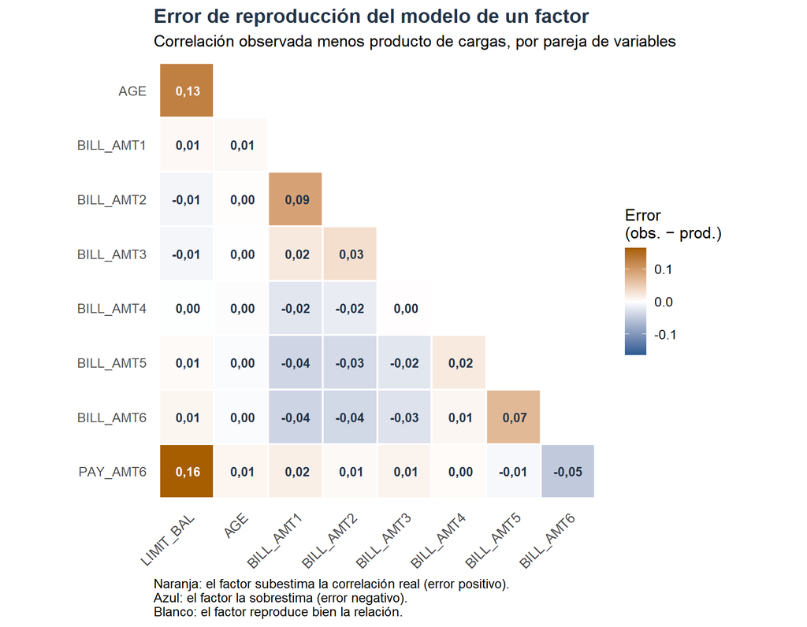

El mayor error es de 0,165 y corresponde a la pareja *PAY_AMT6* y *LIMIT_BAL*. Esto es coherente con el análisis de parte común y parte propia, pues son variables que comparten poco con el factor.

# Cálculo con un segundo factor

A continuación se evalúa si un segundo factor mejora la representación de las correlaciones, en particular las de las variables que el primer factor explica peor.

```r
modelo_fa_2 <- psych::fa(
  datos_kmo,
  nfactors = 2,
  fm = "ml",
  rotate = "oblimin"
)

# Comparación global: un factor vs. dos factores.
c(
  comun_con_un_factor        = round(100 * mean(modelo_fa$communality), 1),
  comun_con_dos_factores     = round(100 * mean(modelo_fa_2$communality), 1),
  rmsr_un_factor             = round(modelo_fa$rms, 3),
  rmsr_dos_factores          = round(modelo_fa_2$rms, 3),
  correlacion_entre_factores = round(modelo_fa_2$Phi[1, 2], 2)
)
```

[output not shown]

```r
# Cargas (patrón) con dos factores, ordenadas por factor dominante.
cargas_2 <- round(unclass(modelo_fa_2$loadings), 2)
cargas_2[order(apply(abs(cargas_2), 1, which.max), -apply(abs(cargas_2), 1, max)), ]
```

[output not shown]

Además, *LIMIT_BAL*, *PAY_AMT6* y *AGE* siguen sin cargar de forma relevante en ninguno de los dos factores, por lo que el segundo factor no resuelve su bajo ajuste.

Por lo anterior, no se incorpora un segundo factor en este análisis: la mejora en el RMSR (de 0,044 a 0,036) y en la comunalidad promedio no justifica añadir un factor que apenas puede interpretarse.

# Rotación de la solución de dos factores

## Girando Factores

```r
f_sin <- psych::fa(datos_kmo, nfactors = 2, fm = "ml", rotate = "none")
f_ind <- psych::fa(datos_kmo, nfactors = 2, fm = "ml", rotate = "varimax")
f_jun <- psych::fa(datos_kmo, nfactors = 2, fm = "ml", rotate = "oblimin")
tabla_giro <- data.frame(
  variable          = colnames(datos_kmo),
  independientes_F1 = round(f_ind$loadings[, 1], 2),
  independientes_F2 = round(f_ind$loadings[, 2], 2),
  correlac_F1       = round(f_jun$loadings[, 1], 2),
  correlac_F2       = round(f_jun$loadings[, 2], 2),
  row.names = NULL
)
tabla_giro
```

| variable | independientes_F1 | independientes_F2 | correlac_F1 | correlac_F2 |
| --- | --- | --- | --- | --- |
| LIMIT_BAL | 0.23 | 0.19 | 0.22 | 0.09 |
| AGE | 0.03 | 0.05 | 0.01 | 0.05 |
| BILL_AMT1 | 0.48 | 0.83 | -0.02 | 0.98 |
| BILL_AMT2 | 0.50 | 0.85 | -0.01 | 1.00 |
| BILL_AMT3 | 0.61 | 0.73 | 0.33 | 0.65 |
| BILL_AMT4 | 0.74 | 0.61 | 0.70 | 0.29 |
| BILL_AMT5 | 0.85 | 0.50 | 1.01 | -0.03 |
| BILL_AMT6 | 0.82 | 0.49 | 0.97 | -0.02 |
| PAY_AMT6 | 0.10 | 0.15 | 0.01 | 0.17 |

```r
c(correlacion_entre_factores_oblimin = round(f_jun$Phi[1, 2], 2))
```

```
## correlacion_entre_factores_oblimin
##                               0.88
```

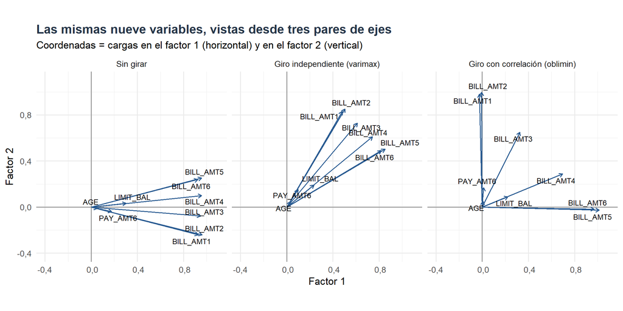

En este caso el giro lo que hizo, fue retratar el mismo comportamiento, realmente tanto las variables de *LIMIT_BAL*, *AGE* y *PAY_AMT_6* son las que menos influyen respecto al resto, se mueven juntas con algunos valores de facturación tanto si se realiza con correlación o de forma independiente, pero sus mnagnitudes no son muyu grandes. Aparte el giro hacia el segundo factor no reveló mucho como para poder nombrarlo algo ditinto del primero.

## Estabilidad Segundo Factor

```r
f_otro <- psych::fa(datos_kmo, nfactors = 2, fm = "minres", rotate = "oblimin")
otro <- round(unclass(f_otro$loadings), 2)
colnames(otro) <- c("F1", "F2")
otro
```

```
##             F1    F2
## LIMIT_BAL 0.00  1.00
## AGE       0.01  0.14
## BILL_AMT1 0.91  0.01
## BILL_AMT2 0.95 -0.01
## BILL_AMT3 0.96 -0.01
## BILL_AMT4 0.96  0.00
## BILL_AMT5 0.95  0.01
## BILL_AMT6 0.91  0.00
## PAY_AMT6  0.12  0.18
```

```r
c(correlacion_entre_factores_minres = round(f_otro$Phi[1, 2], 2))
```

```
## correlacion_entre_factores_minres
##                              0.31
```

Con el otro método de separación todo quedo cargado hacia el límite de cupo, viendo un aumento en el segundo factor hacia el pago del mes de abril y la edad, pero que no es muy significativo, con lo que efectivamente cada una de ellas describen cosas distintas y entre ellas tres no tienen respecto al segundo factor algo en comun. Como ya se dijo el data set no esta hecho para el analisis con 2 factores.

## Traslape entre los dos perfiles

Clientes que quedan en el 20 % más alto de cada factor (puntajes con el giro oblimin).

```r
f_pun <- psych::fa(
  datos_kmo, nfactors = 2, fm = "ml", rotate = "oblimin", scores = "regression"
)
H <- f_pun$scores

alto <- function(v) v >= quantile(v, 0.80)
perfil_1 <- alto(H[, 1])
perfil_2 <- alto(H[, 2])

c(
  perfil_1              = sum(perfil_1),
  perfil_2              = sum(perfil_2),
  en_los_dos            = sum(perfil_1 & perfil_2),
  de_cada_100_repetidos = round(100 * sum(perfil_1 & perfil_2) / sum(perfil_1), 1)
)
```

```
##              perfil_1              perfil_2            en_los_dos
##                6000.0                6000.0                1988.0
## de_cada_100_repetidos
##                  33.1
```

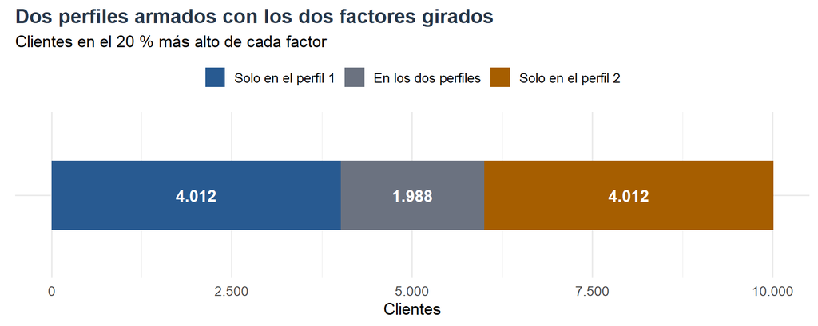